# The responsibilities of decontextualisers

*Diversity and Decolonisation in Mathematics and its Applications*

Tim Hosgood, Topos Institute

8th of April, 2026

# About this talk

## Who am I?

*Why start by telling you about myself?*

## Who am I?

- Trained as a mathematician
- Mathematical translation as a hobby
- Social Impact Lead at [Topos Institute](https://topos.institute)

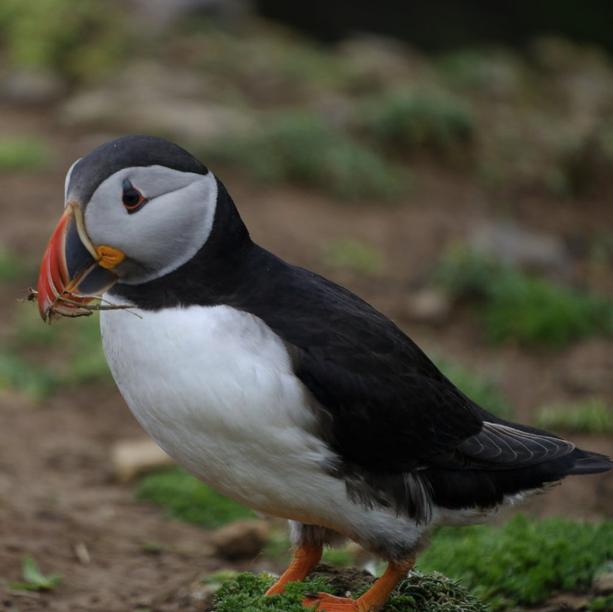

[figure not shown]

## What do I work on?

- Social Impact Lead
  - Contextual technologies
  - Community building
  - Outreach
  - … ?
- Researcher / Research-software engineer
  - Category theory
  - CatColab

## CatColab

*Tools for collaborative modelling and open science*

AlgebraicJulia → ModelCollab → CatColab

Public health, agro-ecology, cyber-physical systems, education, …

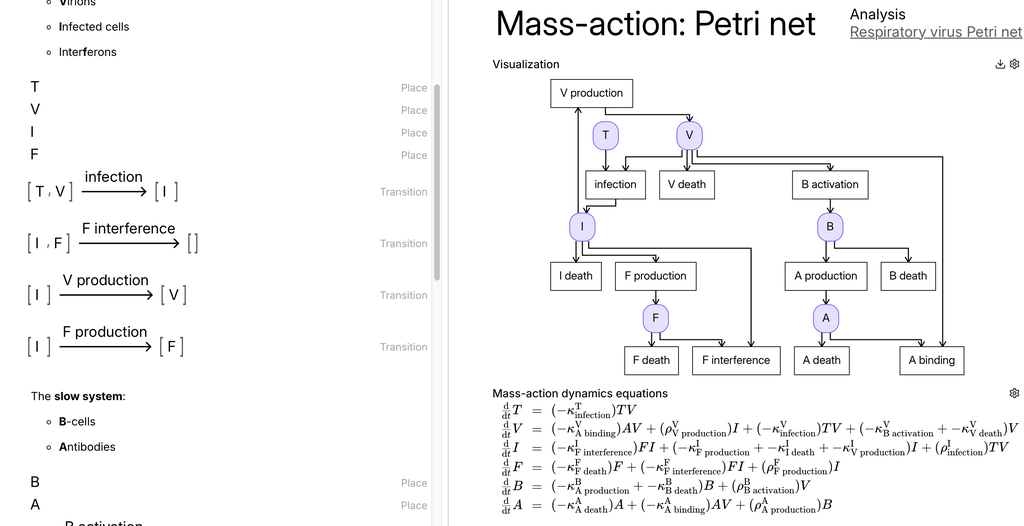

## This talk

- The start of a reading list for people from a similar background to me?
- An experiment in commentary within mathematics?
- A first step for reflection before action?
- A bunch of things that I’ve put in a bag?

> Embarking on a journey means we don’t know the answers, and perhaps just have a smattering of helpful questions. We don’t know the answers, but that’s not bad. The work of decoloniality is not about knowing the answers; it is about staying with the tensions of not-knowing long enough to be changed by them.

> — Akómoláfé, “Paraphilanthropy”.

# One story to start

## The Man Who Invented Modern Probability (1)

> As a young man, Kolmogorov […] presented a paper to a group of his peers at Moscow University, offering an unconventional statistical analysis of the lives of medieval Russians. It found, for example, that the tax levied on villages was usually a whole number, while taxes on individual households were often expressed as fractions. The paper concluded, controversially for the time, that taxes were imposed on whole villages and then split among the households, rather than imposed on households and accumulated by village.

Gerovitch “The Man Who Invented Modern Probability”.

Mathematics can help to call out power.

## The Man Who Invented Modern Probability (2)

> “You have found only one proof,” was his professor’s acid observation. “That is not enough for a historian. You need at least five proofs.” At that moment, Kolmogorov decided to change his concentration to mathematics, where one proof would suffice.

Gerovitch “The Man Who Invented Modern Probability”.

Mathematics is not all.

# *Stories:* Objective truth and messy people

## Two narratives on mathematicians

> *Internalist/platonic approach* (discover what is already there) vs *externalist approach* (heroic mathematical subjectivity) [from Hottinger, *Inventing the Mathematician*.]. Either an identity of a mathematician is totally erased behind the discovery, or it is a hero changing the world… In any case, it is not a woman, nor a non-white person, nor a poor person.

Paris-Romanskevich *Which Results of Gender and Science Every Mathematician Should Know*.

## The Carrier Bag Theory of Fiction

> If science fiction is the mythology of modern technology, then its myth is tragic. “Technology”, or “modern science” (using the words as they are usually used, in an unexamined shorthand standing for the “hard” sciences and high technology founded upon continuous economic growth), is a heoric undertaking, Herculean, Promethean, conceived as triumph, hence ultimately as tragedy.

Le Guin *The Carrier Bag Theory of Fiction*.

## Informatics of the Oppressed

> The history of technology is too often told as a linear progression, as a series of tales of triumphant inventors, emanating mainly from North America and Western Europe. Such tales are pervasive in part because they are easy to tell. […]

> Such commonplace narratives serve important ideological functions.[…] in the case of search engines, it means forgetting the librarians (whose feminized labor is never valued as creative) and the information scientists whose cumulative work over the course of decades laid the foundation for Google.

Ochigame “Informatics of the Oppressed”.

## Informatics of the Oppressed

> More insidiously, such narratives also serve to sanction the dominant technologies by presenting them as the only ones ever conceivable. They overlook the many possible alternatives that did not prevail, thereby producing the impression that the existing technologies are just the inevitable outcome of technical ingenuity and good sense.

Ochigame “Informatics of the Oppressed”.

## The Divided Self

> There is a common illusion that one somehow increases one’s understanding of a person if one can translate a personal understanding of him into the impersonal terms of a sequence or system of *it*-processes.

Laing *The Divided Self*.

## The Divided Self

> If it is held that to be unbiased one should be ‘objective’ in the sense of depersonalizing the person who is the ‘object’ of our study, any temptation to do this under the impression that one is thereby being scientific must be rigorously resisted. […] Although conducted in the name of science, such reification yields false ‘knowledge’. It is just as pathetic a fallacy as the false personalization of things.

> […]

> It is interesting, for example, that one frequently encounters ‘merely’ before subjective, whereas it is almost inconceivable to speak of anyone being ‘merely’ objective.

Laing *The Divided Self*.

## Pedagogy of the Oppressed

> Authentic education is not carried on by “A” *for* “B” or by “A” *about* “B”, but rather by “A” *with* “B”, mediated by the world—a world which impresses and challenges both parties, giving rise to views or opinions about it.

> […]

> We simply cannot go to the laborers—urban or peasant [—] to give them “knowledge” or to impose upon them the model of the “good man” contained in a program whose content we have ourselves organized.

Friere *Pedagogy of the Oppressed*.

## Inventing the Mathematician

> Many understand mathematics to be separate from human concerns and call mathematical knowledge value-free. I argue that we cling to this understanding of mathematics — a rational, universal system that relies on logic to arrive at truth — because it is a key component of how the West understands itself.

Hottinger *Inventing the Mathematician*.

# Rethinking the formal

## The power of stories

Whether we like it or not, “we” shape what is seen as *truth* or *inarguable fact*.

The more we distance ourselves from this, the more we open up to being quoted against our beliefs.

## Evolution of my understanding

*In the context of tools for collaborative, multi-disciplinary modelling*

1. How do we mathematize models to make them formal?
2. How do we extract a formal object from a model?
3. How can we derive a formal object from a model?
4. How can we redefine “formal”?

## The process as primary

We should not confuse a process with its outcome.

- “Sometimes the purpose of building a model is building a model”
- “Sometimes the important part of translation is the act of translation”

# *Stories:* Funding and power

## Quantum Scientists for Disarmament: a Manifesto

> The expansion of military funding for both basic and applied research on emerging technologies, including quantum technologies, is not limited to the world’s major military powers. In a broader context, this opaque expansion often takes the form of asymmetric military-academic partnerships between the defense departments of powerful nations and academic institutions of the Global South. This strategy serves as a subtle mechanism through which hegemonic countries impose their “soft” power over nations of the Global South. For instance, from the perspective of states that can spend less of their public money on science, these funds can support projects that would not be executed otherwise, and help maintain pre-existing infrastructure and personnel, appearing as nearly irrecusable offers […]

Quantum Scientists for Disarmament *Quantum Scientists for Disarmament*.

## Paraphilanthropy (1)

> Minorities indeed need to survive; representation does matter. And inclusion, while fraught with risks, can open up to new practices that prove emancipatory and transformative. However, if we were to leave it here, if we were to centralize the public good, we risk reinforcing neurotypical values. If we were to stick exclusively to dominant critiques of philanthrocapitalism, we risk returning to convergence patterns. *We risk installing solar panels on slave ships or building nice sidewalks in the plantation – when the thing to do now, it seems, is to break away from the labour of neurotypicality.*

Akómoláfé “Paraphilanthropy”.

## Paraphilanthropy (2)

> However […] the discourse around inclusivity and access often leave out the ‘violent’ ways bodies are forced to fit in, what is left out in so doing, and how eventual belonging is always a negotiating away of potentially emancipatory materials.

> For instance, even when an organization has decision-making members with diverse backgrounds and perspectives, the kinds of problems and challenges that demand an executive ‘decision’ (and the ingredients available to work with) often necessitate a homogenization of approaches, exerting pressure upon a group to act in ways that preserve certain outcomes.

> […]

> But giving people what they need to succeed in a fair and equitable way doesn’t quite address the racializing effects of what they now need to be succeeding at.

Akómoláfé “Paraphilanthropy”.

# Community as mathematics as mathematician

## Accessibility

*Within an artefact*, sometimes accessibility means *more* formalism, sometimes *less*, and sometimes some entirely orthogonal amount.

*Outside an artefact*, “open access” does not guarantee “openly accessible”.

## The need for interdisciplinarity

What does healthy funding look like?

We should aspire for (or really, *insist upon*) healthy relationships between

- individuals
- institutes
- funding bodies
- “the public”
- the past
- the now
- the future

# *Stories:* Contextual applications

## The Limits of Data

> An optimist might hope to get around these problems with better data and metrics. What I want to show here is that these limitations on data are no accident. [The intrinsic properties of data collection techniques that give it power also] limit the kinds of information that we can collect.

> […]

> Data is portable, which is exactly what makes it powerful. But that portability has a hidden price: to transform our understanding and observations into data, we must perform an act of decontextualization.

> […]

> The power of data is vast scalability; the price is context.

Nguyen “The Limits of Data”.

## Mathematical Models of Global Development

> Since the 1970s, mathematical models of global development, population, and resources have shaped academic and policy debates about humanity’s future. A landmark in this tradition was the Club of Rome’s *Limits to Growth* project, which used system dynamics to warn of potential ecological and economic collapse under prevailing trends. In contrast, the Bariloche Foundation’s *Latin American World Model* offered a normatively distinct alternative, arguing that global crises arise primarily from structural inequality and political-economic arrangements rather than absolute physical scarcity.

(Barany and de Paiva; de Paiva, in preparation)

## Mathematical Models of Global Development

> The Club of Rome models […] employ coupled nonlinear differential equations with feedback loops representing global stocks and flows of population, capital, resources, pollution, and technology. These models emphasize dynamic instability, overshoot, and collapse under certain growth trajectories. […]

> The Latin American World Model, by contrast, was explicitly normative. Its mathematical structure encoded goals related to the satisfaction of basic human needs, redistribution mechanisms, and equity across regions. Rather than predicting collapse, it sought to demonstrate the feasibility of global wellbeing under alternative socio-economic arrangements. These differing mathematical commitments shape not only the conclusions of the models but also their reception and longevity.

Barany and de Paiva; de Paiva, in preparation

## AI for Whom? Shedding Critical Light on AI for Social Good

> AI4SG is generally referred to as an umbrella term for a sub-discipline of computing whose aim is to utilise AI to alleviate some of societies greatest challenges […]

> While AI4SG projects propose AI as a solution for major societal problems like global health or climate change, they often ignore the fact that social problems are inherently economical, historical, political, cultural and therefore require many different types of interventions.

Moorosi et al. *AI for Whom? Shedding Critical Light on AI for Social Good*.

## AI for Whom? Shedding Critical Light on AI for Social Good

> […] for AI4SG solutions to truly be effective, they should include and empower local stakeholders who are the people for whom the solution should work and are also the people who will maintain the system when the project ends and who have real-world expertise regarding the problem at hand and the solution it requires […]

> In many of the top AI conferences, the AI4SG tracks and workshops often only have projects that are at the level of a minimum-viable product. We wish to make a call to the community to also explicitly seek projects that highlight how to run sustainable AI4SG projects post-deployment.

Moorosi et al. *AI for Whom? Shedding Critical Light on AI for Social Good*.

## Pan-African Declaration on the Future of Biodigital Technologies in Food and Agriculture

> This historic convening brought together over 130 participants from 33 African countries, representing farmers, pastoralists, fisherfolk, women, youth, faith-based communities, scientists, policy makers, lawyers, consumers, Indigenous peoples, civil society organizations, and social movements.

> […]

> Plenary discussions exposed how artificial intelligence and digital platforms replicate colonial patterns of extraction and surveillance.

> Across these spaces, common themes emerged: the urgent need for collective control over data, genetic resources, and digital infrastructures.

First Pan-African Convening on the Future of Biodigital Technologies in Food and Agriculture “Pan-African Declaration on the Future of Biodigital Technologies in Food and Agriculture”.

## Pan-African Declaration on the Future of Biodigital Technologies in Food and Agriculture

> Technologies are not neutral; they reflect and reproduce systems of power. Artificial intelligence industry is emerging as an imperial force. Africa must not be a testing ground for corporate-driven biodigitalization. At the same time, we recognize that digital technologies hold opportunities to connect movements, strengthen local and territorial markets, and support farmer-to-farmer knowledge sharing. […] We affirm the need for non-extractive technologies co-created with communities and firmly anchored in human rights.

First Pan-African Convening on the Future of Biodigital Technologies in Food and Agriculture “Pan-African Declaration on the Future of Biodigital Technologies in Food and Agriculture”.

# Mathematics as decontextualisation

## Numbers as shadows

> Data is portable, which is exactly what makes it powerful. But that portability has a hidden price: to transform our understanding and observations into data, we must perform an act of decontextualization.

## Thank you

### Bibliography

Akómoláfé, Báyò. “Paraphilanthropy: Giving Money Its Freedom Papers.” 2024. https://www.bayoakomolafe.net/post/paraphilanthropy-giving-money-its-freedom-papers.

First Pan-African Convening on the Future of Biodigital Technologies in Food and Agriculture. “Pan-African Declaration on the Future of Biodigital Technologies in Food and Agriculture.” 2025. https://www.etcgroup.org/content/declaration-pan-african-convening-future-biodigital-technologies-food-and-agriculture.

Friere, Paulo. *Pedagogy of the Oppressed*. The Continuum Publishing Company, 1970.

Gerovitch, Slava. “The Man Who Invented Modern Probability.” 2013. https://nautil.us/the-man-who-invented-modern-probability-234497.

Hottinger, Sara N. *Inventing the Mathematician*. SUNY Press, 2016.

Laing, R. D. *The Divided Self*. Tavistock Publications, 1960.

Le Guin, Ursula K. *The Carrier Bag Theory of Fiction*. 1986.

Moorosi, Nyalleng, Raesetje Sefala, and Sasha Luccioni. *AI for Whom? Shedding Critical Light on AI for Social Good*. 2023. https://openreview.net/forum?id=vjwYYlA8Pj.

Nguyen, C. Thi. “The Limits of Data.” *Issues in Science and Technology* XL (2024). https://issues.org/limits-of-data-nguyen/.

Ochigame, Rodrigo. “Informatics of the Oppressed.” *Logic(s)* 11 (2020). https://logicmag.io/care/informatics-of-the-oppressed/.

Paris-Romanskevich, Olga. *Which Results of Gender and Science Every Mathematician Should Know*. 2026.

Quantum Scientists for Disarmament. *Quantum Scientists for Disarmament: A Manifesto*. 2026. https://arxiv.org/abs/2601.14282.